# Notebook

### Probability distributions

2.1 Discrete distributions

2.2 Continuous distributions

A **random variable** is a value determined by chance (informal definition).  
We usually use a **capital letter** to denote a random variable.

**Example:**  
Let $X$ be the result of rolling a fair (balanced) die once.

Then $X$ may take the values $1, 2, 3, 4, 5,$ or $6$ by chance.

## How Do We Describe a Random Variable Mathematically?

A **probability distribution** tells us the possible values of a random variable and the corresponding probabilities of those values.

For the die example, $$ P(X = k) = \frac{1}{6}, \quad k = 1, 2, 3, 4, 5, 6. $$

## Types of Random Variables

### Discrete Random Variables

The possible values can be listed or counted.  
The probability distribution of a discrete random variable is called a **Probability Mass Function (PMF)**.

$$ P(x) = P(X = x) = p_x, $$

where $x$ is one of a list of specific values.

### Continuous Random Variables

Any value within a given range can be a possible value.

**Example:**  
The speed of a train — any value between 0 and 100 miles per hour.

## Mean (Expected Value)

The mean, or **expected value**, of a discrete random variable $X$ is $$ E[X] = \sum_x x p_x, $$ where $p_x$ is the probability that $X$ takes the value $x$.

The expected value is a **weighted average** of all possible values.

## Example

Suppose an individual plays a gambling game with the following outcomes and probabilities:

| Outcome ($) | -2.00 | 0.00 | 20.00 | 100.00 |
| --- | --- | --- | --- | --- |
| Probability | 0.75 | 0.15 | 0.049 | 0.001 |

Find the expected value of the distribution.

$$ \begin{aligned} E[X] &= (-2)(0.75) + (0)(0.15) + (20)(0.049) + (100)(0.001) \\ &= -1.5 + 0 + 0.98 + 0.10 \\ &= -0.42. \end{aligned} $$

This means that, in the long run, the average loss per game is $0.42.

## Variance of a Discrete Random Variable

The variance of a discrete random variable is given by $$ \operatorname{Var}(X) = E[X^2] - (E[X])^2. $$

## 2.1.1 Special Discrete Random Variables

### A. Bernoulli Distribution

A random variable $X$ is said to have a **Bernoulli distribution** with parameter $p$ if $$ X \sim \mathrm{Bernoulli}(p), \quad 0 \le p \le 1. $$

- **Support:** $x \in \{0, 1\}$
- **Probability Mass Function (PMF):**

$$ P(X = x) = p^x (1 - p)^{1 - x}, \quad x \in \{0, 1\}. $$

**Example:**  
Toss a coin once, where the probability of obtaining a head (success) is $p$.

### B. Binomial Distribution

A random variable $X$ is said to have a **Binomial distribution** with parameters $n$ and $p$ if $$ X \sim \mathrm{Binomial}(n, p), \quad n \in \mathbb{N}, \; 0 \le p \le 1. $$

- **Support:** $x = 0, 1, \dots, n$
- **Probability Mass Function (PMF):**

$$ P(X = x) = \binom{n}{x} p^x (1 - p)^{n - x}, \quad x = 0, 1, \dots, n. $$

A binomial random variable models the **number of successes** in a fixed number of independent and identical trials, where each trial has the same probability of success.

**Example:**

Let $X$ be the number of heads obtained when tossing a fair coin 9 times.

Then $X$ has a binomial distribution with

- $n = 9$ (the number of trials), and
- $p = 0.5$ (the probability of success in each trial).

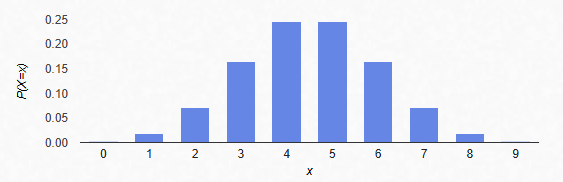

### C. Poisson Distribution

A random variable $X$ is said to have a **Poisson distribution** with parameter $\lambda$ if $$ X \sim \mathrm{Poisson}(\lambda), \quad \lambda > 0. $$

- **Support:** $x = 0, 1, 2, \dots$
- **Probability Mass Function (PMF):**

$$ P(X = x) = e^{-\lambda} \frac{\lambda^x}{x!}, \quad x = 0, 1, 2, \dots $$

A Poisson random variable models the **number of occurrences of an event** in a fixed amount of time, space, or distance, assuming that the event occurs at a **constant average rate** $\lambda$ and that occurrences are independent.

**Examples:**

1. The number of phone calls received in one hour ($0, 1, 2, \dots$).
2. The number of hurricanes in Texas next year.
3. The number of DNA mutations in a segment of DNA.

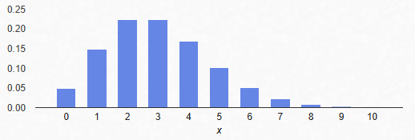

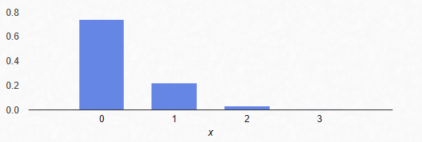

Parameter $\lambda$: the rate of occurences.

# Probability calculation for these special distributions

Q1: A marksman hits a target 80% of the time. He fires five shots at the target. What is the probability that exactly 3 shots hit the target? What is the probability that no more than 3 shots hit the target?

What distribution is needed?

```
 p = 0.8 (probability of a success)

 5 trials

Binomial distribution is to model the number of hits (successes) out of 5 shots.

P(The number of hits = 3) = P(X = 3) = 0.2048
```

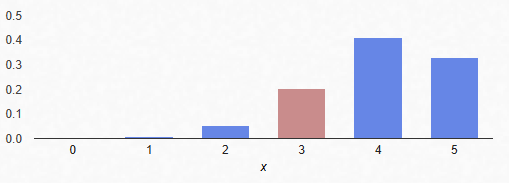

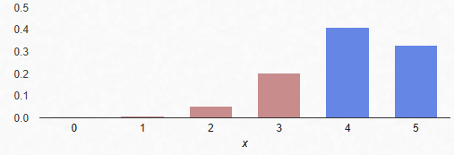

```r
#Binomial distribution probability calculation
   dbinom(x=3, size=5, prob=0.8)
```

0.2048

```r
#What is the probability that no more than 3 shots hit the target?
  sum(dbinom(x=0:3, size=5, prob=0.8))

#pbinom is the find the probability of no more than x successes
  pbinom(3, size=5, prob=0.8)
```

0.26272

0.26272

### Negative Binomial Distribution

A negative binomial distribution is to model the number of failures procede (until) the $r$-th success.

A negative binomial distribution has two parameters: $r$ (the required number of successes) , p = Probability of a success

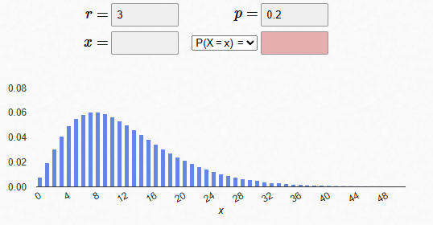

Counting the number of trials (successes + failures) required to achieve a specified number of successes.

the number of trials = the number of failures + r

A success = a type of the results

A failure = all other types of the results

The mean of a negative binomial is

$EX = r/p - r = r(1-1/p) = r (1-p)/p$

Flipping a coin: a success = a head, a failure = a tail

Check if a component is defective or not: a success = A defective item , a failure = a non-defective item.

Example: In a clinical trial, a treatment has a 30% probability of success for each patient. Let $X$ be the number of patients treated until 5 successful responses are observed. $$ X \sim \text{Negative Binomial}(r = 5, p = 0.3) + 5 $$

Example: A student is selling candy door to door to raise money for a school fundraiser. Each household independently agrees to buy candy with probability 0.2. The student wants to sell candy to 5 households.  
What is the distribution of the number of house where he does not make a sell until he sell candy to 5 household?

```
       A success = A house with a sell

       r = 5

       p = probability of a success in one trial = 0.2

       Negative binomial with r = 5,  p = 0.2
```

In average, how many houses does the kid need to visit until he sell 5?

```
    Expecte number of trials =   r/p = 5/0.2 = 25
```

Intutively, a negative binomial is related to model the effort needed to acheive a goal (r-th success).

Many biological count data exhibit **overdispersion**, where the variance exceeds the mean, violating the Poisson assumption.

The mean, the variance

**Examples:**

- Number of parasites per host
- RNA-seq gene expression read counts
- Number of insects per plant
- Disease case counts across regions

```r
#Example: A student is selling candy door to door to raise money for a school fundraiser. Each household independently agrees to buy candy with probability 0.2. The student wants to sell candy to 5 households.
# Find the probability that the student needs to visit 12 houses until the student sells 5.

# P(12 trials until the 5-th success) =  P( The number of failures X =  7 until 5th sucess  )

#negative binomial probability calculation
dnbinom(7,  size = 5 , prob = 0.2 )

#The probability is 0.022 to visist 12 houses until the 5-th sale.
```

0.02214592512

### Choosing the correct discrete distribution depends on **what is fixed** and **what is being counted**.

Use the **Poisson distribution** when:

- An average rate (mean) of events per unit (time, page, distance, area, etc.) is given, and
- You are asked to find the probability of observing **$n$ events** in a fixed interval.

Typical wording includes phrases such as *“on average,” “rate per unit,”* or *“expected number of events.”*

**Example:**

- The number of typos per 100 pages
- The number of phone calls in two hours
- The number of accidents per mile

Use the **Binomial distribution** when:

- There is a fixed number of trials $n$, and
- Each trial can be grouped into only two outcomes (success/failure), with
- A known (or implied) probability of success $p$, and
- You are asked for the probability of **$k$ successes out of $n$ trials**.

Typical wording includes phrases such as *“out of,” “exactly $k$,”* or *“fixed number of trials.”*

**Example:**

- Number of defective items in a sample of $n$ products
- Number of heads in tossing a coin $n$ times

Use the **Negative Binomial distribution** when:

- The probability of success $p$ is fixed, and
- Trials continue **until** (precede, before) a specified number of successes $r$ is reached, and
- You are asked about the number of **failures before the $r$th success** (or equivalently, the total number of trials until $r$ successes).

Typical wording includes phrases such as *“until,” “before,”* or *“how many trials are needed.”*

**Example:**

- Number of customers who do not buy before the $5$th sale
- Number of non-defective items inspected before finding $r$ defective ones

### 2.2 Continuous distributions

To model the driving speed of a randomly selected car in the highway, we may use a density curve: in mathematics, we call it "probablity density function " (pdf)

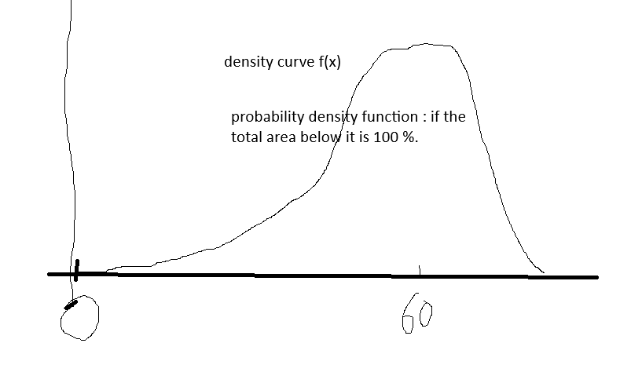

Let $X$ be a continuous random variable with probability density function $f(x)$.

### Probability

$$ P(a \le X \le b) = \int_a^b f(x)\,dx $$

### Expected Value (the mean)

$$ \mathbb{E}[X] = \int_{-\infty}^{\infty} x f(x)\,dx $$

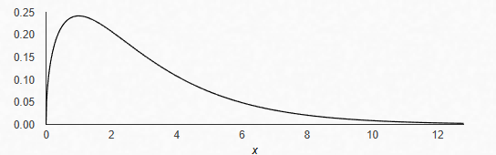

### Variance

$$ \mathrm{Var}(X) = \int_{-\infty}^{\infty} (x - \mathbb{E}[X])^2 f(x)\,dx $$

or $$ \mathrm{Var}(X) = \mathbb{E}[X^2] - (\mathbb{E}[X])^2 $$

### 2.2.1 Normal distributions

History: The Normal distribution was first introduced by **Abraham de Moivre** in 1733 to approximate binomial probabilities. Later, **Carl Friedrich Gauss** (hence "Gaussian") popularized it in the early 19th century for analyzing astronomical and measurement errors. Its importance comes from the **Central Limit Theorem**, which states that sums of many independent random variables tend to follow a Normal distribution, regardless of the original distributions.

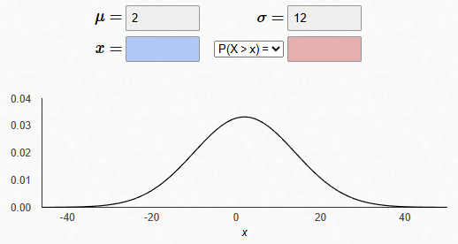

Normal (Gaussian) Distribution $N(\mu,\sigma^2)$ has a Probability Density Function as $$ f(x) = \dfrac{1}{\sqrt{2\pi\sigma^2}} \exp\left(-\dfrac{(x-\mu)^2}{2\sigma^2}\right) $$

where

- $\mu$: mean (location / center of the distribution)
- $\sigma$: standard deviation (spread)
- $\sigma^2$: variance

A normal distribution is bell curved, symetrical, the mean is at $\mu$ and the variance is $\sigma^2$

Why normal distributions are important?

1). Many natural occuring characteristics such as "ph value" of the rain, "height" of all 15 years old males, weights of ... have bell curved patterns if we construct a histogram for the data. A theorical model (normal distributions) happens to describe these patterns very well.

2). Central limit theorm, in the therotical aspects.

A standard normal distribuiton: a normal distribution with the mean of 0 and a standard deviation of 1.
$$Z \sim N(0, 1^2) $$

Example: normal probability calculation

Assume that the birth weight of all males have a normal distribution with a mean of 7 lbs, and a standard deviaiton of 0.75 lbs.

a). Find the probability that the birth weight is between 6.5 and 7.5 lbs.

P(6.5 < Weight < 7.5) =

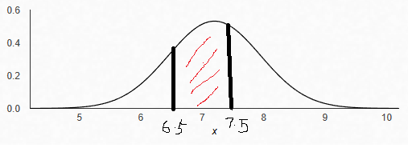

80-th percentile:

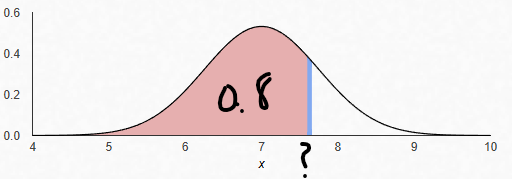

```r
#normal probability calculation
#   pnorm(x , mean, standard deviation) :
#to find the probability no more than x for a normal distribution with mean and the given standard deviation

     pnorm(7.5, mean = 7.0, sd = 0.75, )  #probability no more than 7.5

     pnorm(6.5, mean = 7.0, sd = 0.75, )  #probability no more than 6.5

     pnorm(7.5, mean = 7.0, sd = 0.75, ) - pnorm(6.5, mean = 7.0, sd = 0.75, )

#The answer is 0.495014924906154
```

0.747507462453077

0.252492537546923

0.495014924906154

```r
#What is the 90th percentile of the birth weight?
#80-th percentile :   The probability below or at that value is 0.8

qnorm(0.8, mean=7.0, sd=0.75)
```

7.63121592517969

## 2.2.2 Exponential distributions

Probability Density Function $$ f(x) = \begin{cases} \lambda e^{-\lambda x}, & x \ge 0 \\ 0, & \text{otherwise} \end{cases} $$

Parameters:

- $\lambda$: rate parameter (the same meaning of the parameter in Poisson distributions)
  - Average number of events per unit time
  - Larger $\lambda$ implies shorter expected waiting time

$$ \mathbb{E}[X] = \dfrac{1}{\lambda} $$$$ \mathrm{Var}(X) = \dfrac{1}{\lambda^2} $$

##### Applications

- Time before the next occurence, time between two occurences
- Queueing systems
- Memoryless processes

Example: suppose the service rate is 0.1 customers per minute in a window of the post office. What is the distribution of the waiting time of the next customer?

$X~exp(0.1)$.

EX = 10

The **Exponential distribution** is a special case of the Gamma distribution with shape parameter `α = 1`. It is defined only for positive values and is widely used to model **time until an event occurs**, with a single **rate parameter** `λ > 0` (or scale `θ = 1/λ`), which determines the expected time between events.

- **Reliability Engineering:** Models the time until failure of a component when failures occur at a constant rate. The rate `λ` represents the average frequency of failures, helping engineers estimate product lifetimes and maintenance schedules.
- **Queuing Theory:** Models waiting times between arrivals or services, such as customer arrivals at a bank or calls at a call center. Here, `λ` is the average arrival or service rate, allowing prediction of queue lengths and service efficiency.
- **Meteorology:** Used to model time between rainfall events. The rate `λ` represents the expected frequency of rainfall occurrences.
- **Finance & Insurance:** Models time between claims or financial losses. `λ` reflects the expected frequency of such events, helping actuaries in risk assessment and premium calculation.
- **Survival Analysis / Healthcare:** Models the time until an event such as equipment failure or patient relapse. The rate `λ` corresponds to the hazard rate, representing the instantaneous probability of the event occurring at any given time.

Example: suppose the service rate is 0.1 customers per minute in a window of the post office. Find the probability the waiting time is more than 5 minutes.

$X~exp(0.1)$.

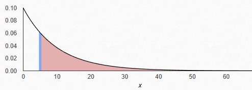

Example: suppose the service rate is 0.1 customers per minute in a window of the post office. Find the 90th percentle of the waiting time.

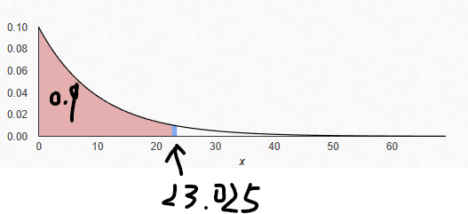

```r
#Probabililty calculation for exponential distribution

#pexp(5, lambda = 0.1)               #Find the probability no more than a number for exponential distribution

#more than 5 minutes
1 - pexp(5, rate = 0.1)
```

0.606530659712633

```r
#Find the 90th percentle of the waiting time.
qexp(0.9, rate = 0.1)
```

23.0258509299405

#### 2.2.3 Gamma Distribution $\Gamma(\alpha,\beta)$

*(Shape $\alpha$, Rate $\beta$)* - Textbook

### Probability Density Function

$$ f(x) = \begin{cases} \dfrac{\beta^\alpha}{\Gamma(\alpha)} x^{\alpha-1} e^{-\beta x}, & x \ge 0 \\ 0, & \text{otherwise} \end{cases} $$

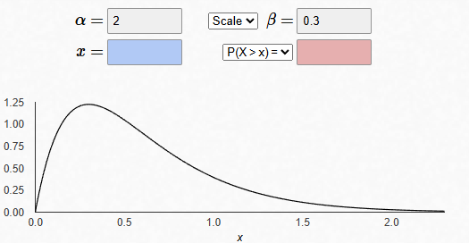

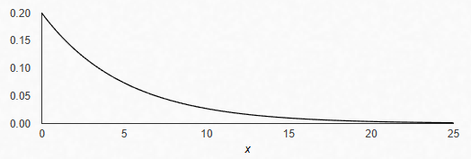

### Parameters Interpretation

- $\alpha$: shape parameter
  - Controls skewness
  - Often interpreted as the number of events
- $\beta$: rate parameter
  - Controls decay speed

### Mean

$$ \mathbb{E}[X] = \dfrac{\alpha}{\beta} $$

### Variance

$$ \mathrm{Var}(X) = \dfrac{\alpha}{\beta^2} $$

### Applications

- Total waiting time for multiple events
- Reliability analysis
- Bayesian inference

Because it is flexible and defined only for positive values, the **Gamma distribution** is widely used in various fields. Its two parameters—the **shape parameter** `α > 0` and the **rate parameter** `β > 0` (or scale `θ = 1/β`)—allow it to model a wide range of behaviors, from highly skewed to nearly symmetric distributions:

Example: suppose the service rate is 0.1 customers per minute in a window of the post office. What is the distribution of the waiting time of if two customers is in front of you?

Waitig time for 3 customers (Waiting time to have the third occurences):

$\Gamma(\alpha = 3,\beta = 0.1)$

#### 2.2.4 Weibull Distributions

The **Weibull distribution** is a flexible probability distribution used to model **lifetimes, failure times, and extreme events**. It is defined only for positive values. Its key parameters are:

- **Shape parameter** $k > 0$ (sometimes denoted as $\beta$): Controls the **failure rate behavior**.
  - $k < 1$: Decreasing failure rate (early failures dominate)
  - $k = 1$: Constant failure rate (reduces to the Exponential distribution)
  - $k > 1$: Increasing failure rate (wear-out failures dominate)
- **Scale parameter** $\lambda > 0$ (sometimes denoted as $\alpha$): Stretches or compresses the distribution along the x-axis; it represents the **characteristic life**.

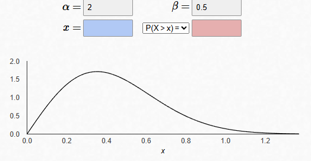

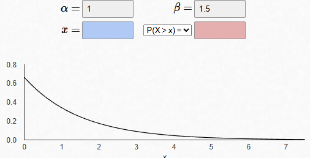

For $x \ge 0$:

$$ f(x; k, \lambda) = \frac{k}{\lambda} \left(\frac{x}{\lambda}\right)^{k-1} e^{-(x/\lambda)^k} $$

Cumulative Distribution Function (CDF)

$$ F(x; k, \lambda) = 1 - e^{-(x/\lambda)^k}, \quad x \ge 0 $$

The **Weibull distribution** is a flexible probability distribution widely used to model **lifetimes, failure times, and extreme events**. It is defined for positive values and has two key parameters:

- **Shape parameter** `k > 0`: Determines the failure rate behavior.
  - `k < 1`: Decreasing failure rate (early failures dominate).
  - `k = 1`: Constant failure rate (equivalent to Exponential).
  - `k > 1`: Increasing failure rate (wear-out failures dominate).
- **Scale parameter** `λ > 0`: Stretches or compresses the distribution along the x-axis, controlling the characteristic life.

#### History

The Weibull distribution was introduced by **Waloddi Weibull** in 1951 to model material strength and reliability. Its flexibility in modeling different failure rates makes it extremely useful in engineering, reliability analysis, and survival studies.

### 2.3 Probability Modelling

```r
Example: use P35 data. What distribution is approproate to model it? Plot a histogram and the theoritical distribution.
```

```r
locdat = "P35.csv"

dat =read.csv(locdat, header = 1)

head(dat)

x = dat$x
x
```

A data.frame: 6 × 1

|  | x <int> |
| --- | --- |
| 1 | 3 |
| 2 | 2 |
| 3 | 5 |
| 4 | 4 |
| 5 | 2 |
| 6 | 5 |

0.326829268292683

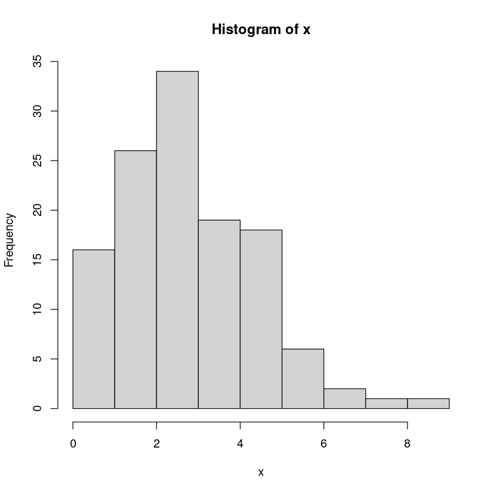

```r
#Suggest a model
#Discrete data - counts
#Binomial (n, p),   Poisson (rate), Negative binomial (r, p), ....
hist(x)

#the data takes whole numbers - discrete
#Binomial (n =10, p =?)
n=10
p = mean(x)/n    #n p = the mean
p

#Informal graphical method
#plot the distribution and over the histgram
```

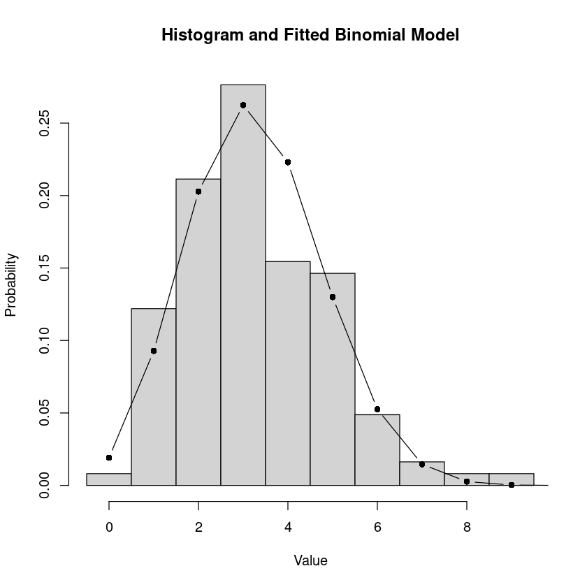

```r
# Support for the fitted model
y = 0:n
pmf = dbinom(y, size = n,  prob = p)             #the probability mass function

# Plot histogram (normalized) and fitted PMF
hist(
  x,
  breaks = seq(-0.5, max(x) + 0.5, by = 1),
  probability = TRUE,
  xlab = "Value",
  ylab = "Probability",
  main = "Histogram and Fitted Binomial Model"
)

#The fitted model
lines(y, pmf, type = "b", pch = 16)
```

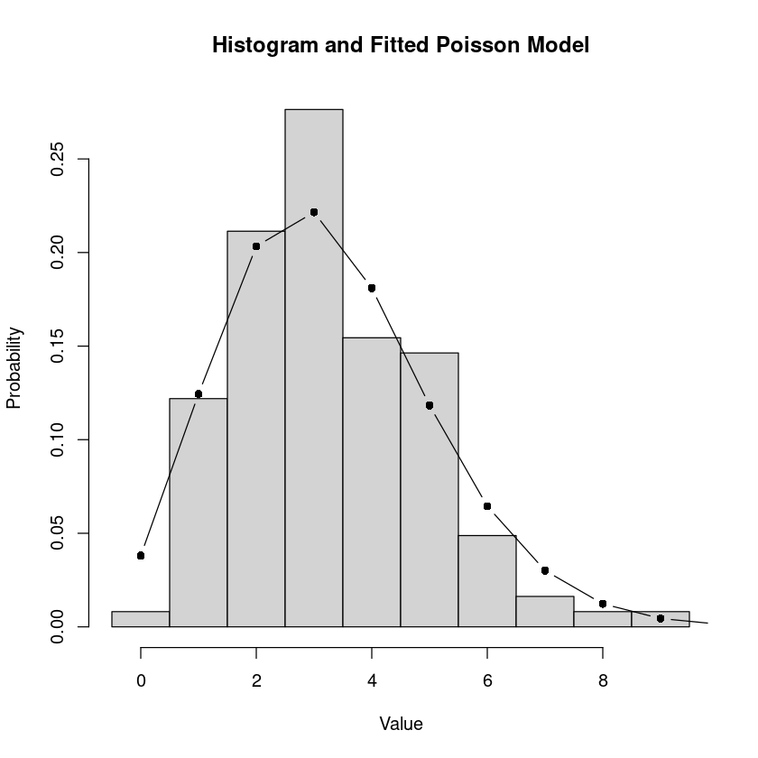

```r
lrate = mean(x)

# Support for the fitted model
y = 0:15
pmf = dpois(y, lambda = lrate)             #the probability mass function



# Plot histogram (normalized) and fitted PMF
hist(
  x,
  breaks = seq(-0.5, max(x) + 0.5, by = 1),
  probability = TRUE,
  xlab = "Value",
  ylab = "Probability",
  main = "Histogram and Fitted Poisson Model"
)

#The fitted model
lines(y, pmf, type = "b", pch = 16)
```

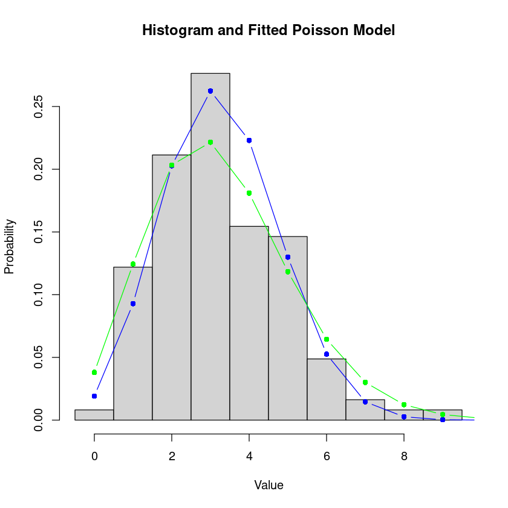

```r
#Please use a Poisson model to fit the data.
# rate = the mean

lrate = mean(x)

# Support for the fitted model

# Support for the fitted model
y1 = 0:n
pmf1 = dbinom(y1, size = n,  prob = p)             #the probability mass function

y2 = 0:15
pmf2 = dpois(y2, lambda = lrate)             #the probability mass function

# Plot histogram (normalized) and fitted PMF
hist(
  x,
  breaks = seq(-0.5, max(x) + 0.5, by = 1),
  probability = TRUE,
  xlab = "Value",
  ylab = "Probability",
  main = "Histogram and Fitted Poisson Model"
)

#The fitted model
lines(y1, pmf1, type = "b", pch = 16, col="blue")
lines(y2, pmf2, type = "b", pch = 16, col="green")
```

### Distributions and the correpsonding paramters summary

[output not shown]

Example: use NORM6478.csv. Please use a suitable distribution to model it.

```r
#Load the data

loc = "NORM6478.csv"


dat = read.csv(loc, header = 1)

head(dat)
```

A data.frame: 6 × 1

|  | x <dbl> |
| --- | --- |
| 1 | 5.430836 |
| 2 | 4.570105 |
| 3 | 5.461254 |
| 4 | 7.035269 |
| 5 | 5.227729 |
| 6 | 5.804957 |

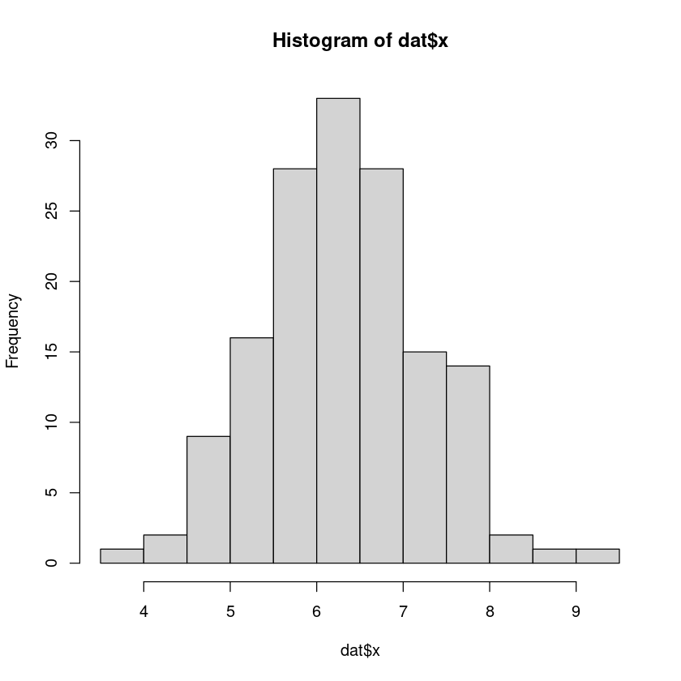

```r
#Look at the shape of the distribution (histgram)

 hist(dat$x)

#Bell curved - short tail  : a normal distribution is a good choice
```

```r
#Two paramters in a normal distribution:  mu (the mean) and sigma (the standard deviation)

#to estimate $\mu$ (the mean)
 muhat = mean(dat$x)
 sigmahat = sqrt(var(dat$x))

 muhat
 sigmahat

 n = length(dat$x)
```

6.31142039759297

0.932324556187396

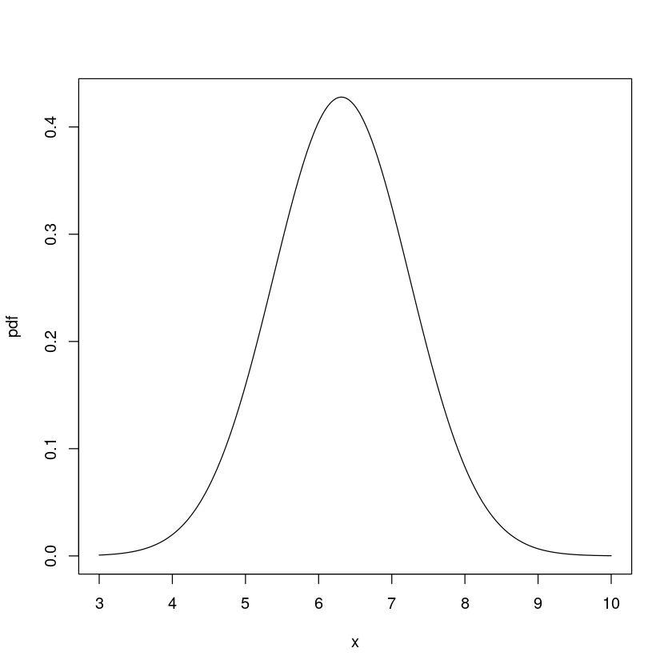

```r
#Plot the normal distribution
x = seq(3, 10, length = 200 )
#To find the probability density of a nornal distribution with the mean and the standard deviation
pdf = dnorm(x, mean=muhat, sd = sigmahat )

plot(x, pdf, type = "l")
```

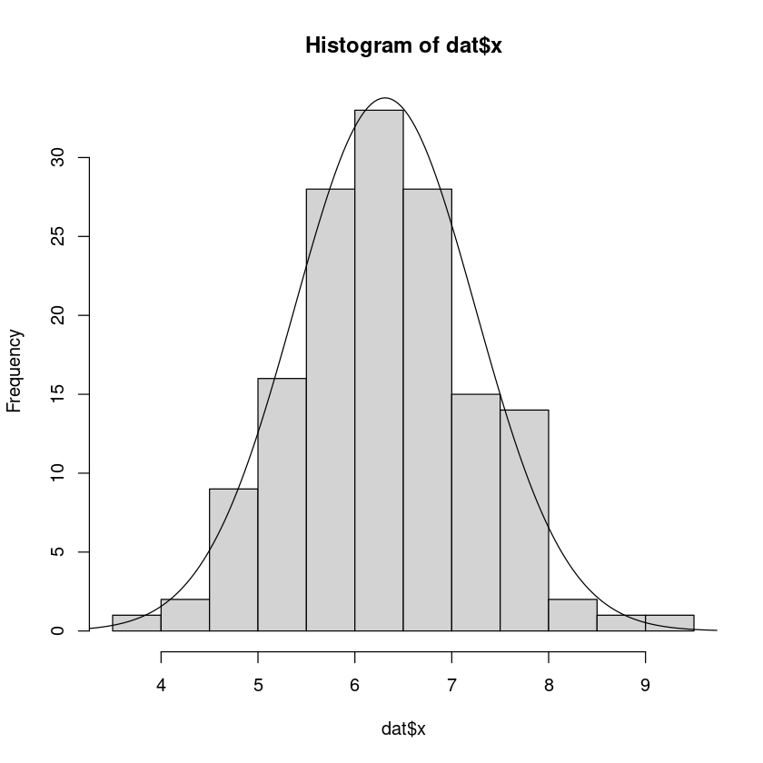

```r
hist(dat$x)

lines(x, pdf*n/1.9, type = "l")

#The normal distribution with the mean of 6.311 and the standard deviation of 0.932 is a theoritcal model to model data.
```

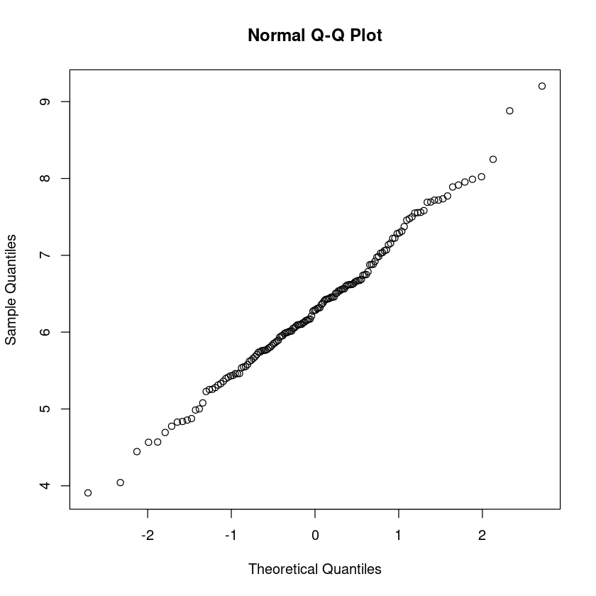

```r
#QQ normal plot
qqnorm(dat$x)

#Roughly, all the points follow a straight line, the data are from a normal distribution approximately.
#If there is a systematic deviation from a straight line in the QQ normal plot, the data may from a non-normal distribution.
```

```r
#goodness of fit test
#normal goodness of fit test
ks.test(dat$x, "pnorm", muhat, sigmahat )

#p-value is 0.7153. It is reasonable to assume that the data are from a normal distribution
#with mean = ... and standard deviation of ...
```

```
	Asymptotic one-sample Kolmogorov-Smirnov test

data:  dat$x
D = 0.056955, p-value = 0.7153
alternative hypothesis: two-sided
```

Example: use EXP033.csv. Please use a suitable distribution to model it.

A data.frame: 6 × 1

|  | x <dbl> |
| --- | --- |
| 1 | 4.42867916 |
| 2 | 3.55325888 |
| 3 | 11.07115792 |
| 4 | 0.01998352 |
| 5 | 4.61269857 |
| 6 | 1.81360128 |

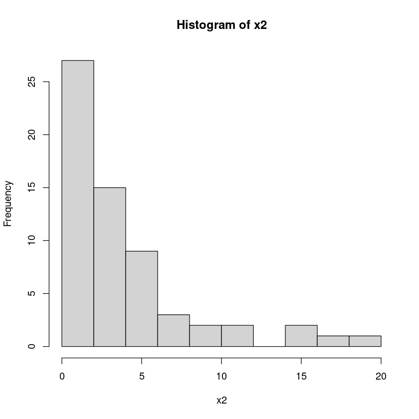

```r
#Load the data

loc = "EXP033.csv"
dat = read.csv(loc, header = 1)
head(dat)

x2 = dat$x

hist(x2)
```

```r
#Can we use a normal distribution?  No
#Exponential distribution may work for this data because it is skewed to the right,
# and similar to the shape of an exponential distribution

lambdahat = 1/mean(x2)

lambdahat

#An exponential distribuiton with lambda (0.255)
```

0.254873013065025

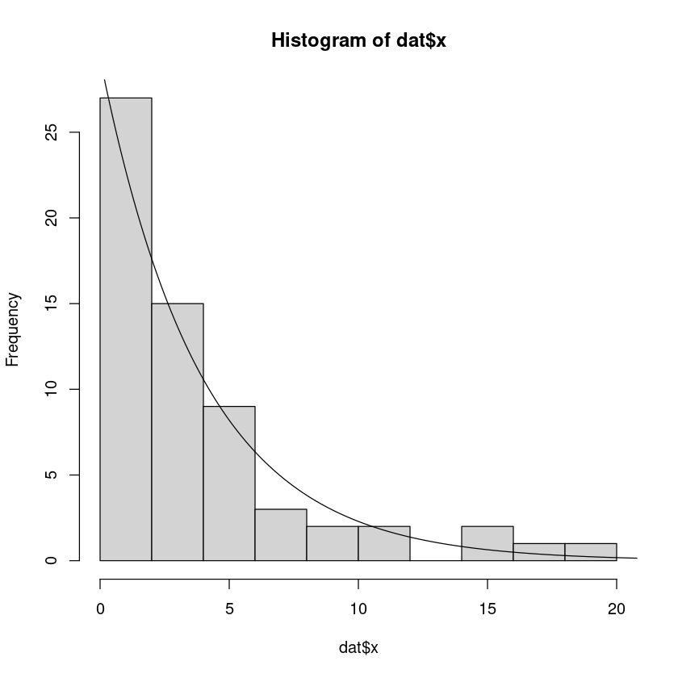

```r
#Plot the exponential distribution
x = seq(0, 26, length = 200 )
#To find the probability density of a nornal distribution with the mean and the standard deviation
pdf = dexp(x, rate = lambdahat)

#plot(x, pdf, type = "l")

hist(dat$x)

lines(x, pdf*115, type = "l")
```

62

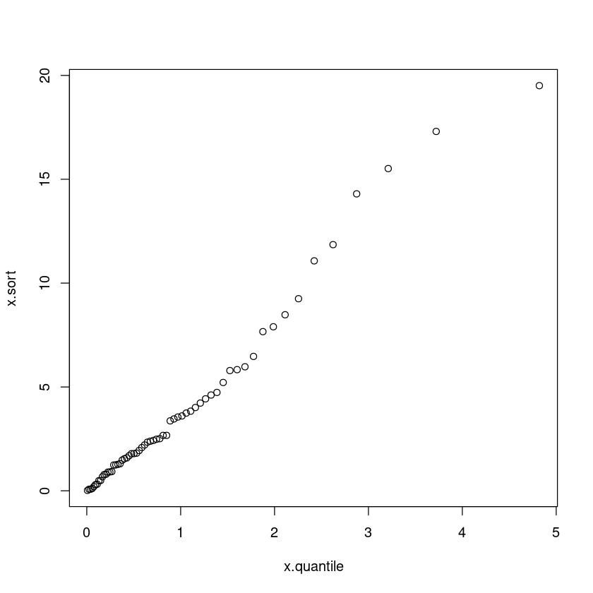

```r
n = length(dat$x)
n

#To make a qq exponential plot
x.sort = sort(dat$x)
q = ((1:n)-0.5)/n
x.quantile =  qexp(q)
plot( x.quantile, x.sort)

#Similiarly, if the points roughly follow a straight line, the data are from an exponential distribtion approximatly.
```

```r
#Goodness of fit test
#perform Kolmogorov-Smirnov test for a normal distribution
ks.test(dat$x, "pnorm")

#perform Kolmogorov-Smirnov test for an exponetial distribution
ks.test(dat$x, "pexp")
```

```
	Exact one-sample Kolmogorov-Smirnov test

data:  dat$x
D = 0.65098, p-value = 7.772e-16
alternative hypothesis: two-sided
```

```
	Exact one-sample Kolmogorov-Smirnov test

data:  dat$x
D = 0.46932, p-value = 4.808e-13
alternative hypothesis: two-sided
```

```r
#perform Kolmogorov-Smirnov test for an exponetial distribution
ks.test(dat$x, "pexp", lambdahat )

#p-value = 0.7006, which is above 0.05 (the level of significance), fail to reject H0.
#It is reasonable to assume that the data are from an expential distribution with rate parameter 0.255.
```

```
	Exact one-sample Kolmogorov-Smirnov test

data:  dat$x
D = 0.087188, p-value = 0.7006
alternative hypothesis: two-sided
```

```r
#https://jse.amstat.org/datasets/babyboom.dat.txt

loc = "https://jse.amstat.org/datasets/babyboom.dat.txt"
#read.table(loc)

dat = read.table(loc)
names(dat)=c("Time", "Sex", "Weight", "time")

head(dat)

#Please carefully review the meaning of the variables, then model it.
#Maybe you have to run some transformation before modelling the variable.
#Sex : two values
```

A data.frame: 6 × 4

|  | Time <int> | Sex <int> | Weight <int> | time <int> |
| --- | --- | --- | --- | --- |
| 1 | 5 | 1 | 3837 | 5 |
| 2 | 104 | 1 | 3334 | 64 |
| 3 | 118 | 2 | 3554 | 78 |
| 4 | 155 | 2 | 3838 | 115 |
| 5 | 257 | 2 | 3625 | 177 |
| 6 | 405 | 1 | 2208 | 245 |

#### 2.4 Mixed distributions

A mixture of 2 or more distribtions.

$$ f(x)=\sum_i \lambda_i f_i(x), \qquad \lambda_i \ge 0,\ \sum_i \lambda_i = 1. $$

Example: provide a distribution model the "waiting time" for R inner data faithful.

```r
data(faithful)
head(faithful)
```

A data.frame: 6 × 2

|  | eruptions <dbl> | waiting <dbl> |
| --- | --- | --- |
| 1 | 3.600 | 79 |
| 2 | 1.800 | 54 |
| 3 | 3.333 | 74 |
| 4 | 2.283 | 62 |
| 5 | 4.533 | 85 |
| 6 | 2.883 | 55 |

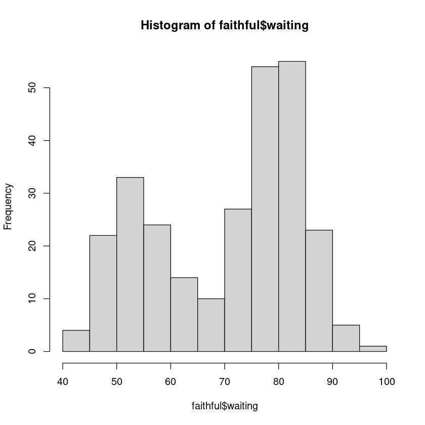

```r
hist(faithful$waiting)
#The histogram shows two modes:  a mixture of two normal distribution
#What is the first normal distribution, what is the second normal distribution,
#what is the proporiton of the first normal, the proportion of the second one.
#
```

```r
library(mixtools)
```

```r
mdl = normalmixEM(faithful$waiting) #normalmixEM is the calculation for a mixed normal distribution.
mdl
```

```
number of iterations= 29
```

[output not shown]

[output cut: 300 more lines]

$$ f(x)= 0.36 f_1 + 0.64 f_2 $$

where $f_1$, $f_2$ are probabililty density functions for the first ad the second normal distributions.

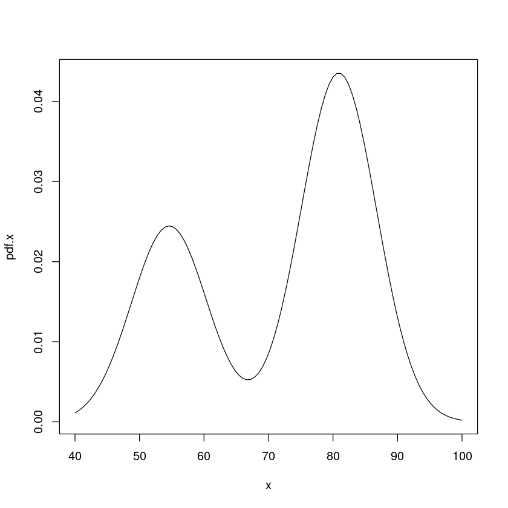

```r
#plot the therotical model

x = seq(40, 100, length=100)

pdf.x = 0.36 *dnorm(x, 54.61, 5.87) + 0.64*dnorm(x, 80.9, 5.86)


plot(x, pdf.x, type = 'l')
```

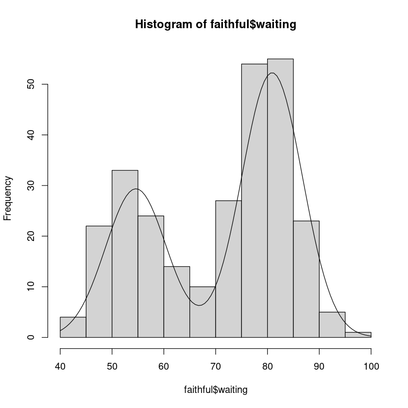

```r
hist(faithful$waiting)

lines(x, 1200*pdf.x, type = "l")
```

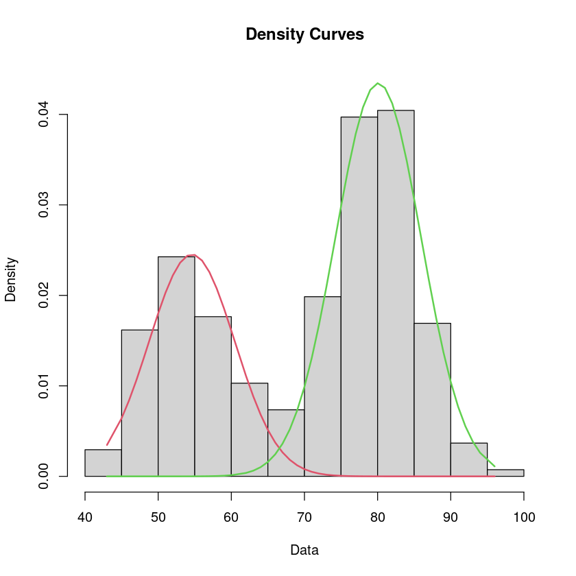

```r
#plot the individual normal distributions
plot(mdl,which=2)
```

```r
#Goodness of fit test to see if the distribution matchs with the data
#Step 1: define a cumulative distribution function of the mixed distribution
pmixed = function(x)
    {
    mcdfatx = 0.36 *pnorm(x, 54.61, 5.87) + 0.64*pnorm(x, 80.9, 5.86)
    return (mcdfatx)
}


#perform Kolmogorov-Smirnov test for an exponetial distribution
ks.test(faithful$waiting, "pmixed")

#p-value = 0.1817, since p-value is above the level of significance 0.05,
#there is no evidence that the data are not from this mixed distribution.
```

```
	Asymptotic one-sample Kolmogorov-Smirnov test

data:  faithful$waiting
D = 0.066393, p-value = 0.1817
alternative hypothesis: two-sided
```

**Formula : the expected value of a mixed distribution given the expected values $\mu_i$ of each component.**

Let the mixed density be $$ f(x)=\sum_i \lambda_i f_i(x), \qquad \lambda_i \ge 0,\ \sum_i \lambda_i = 1. $$ If $$ \mu_i=\int_{-\infty}^{\infty} x\, f_i(x)\,dx, $$ then the mean of the mixture is $$ \mu = \mathbb{E}(X)=\int_{-\infty}^{\infty} x \Big(\sum_i \lambda_i f_i(x)\Big)\,dx = \sum_i \lambda_i \mu_i. $$